# How eutrophisation affect food web structures along the estuary-sea continuum

## Summary

```r
library(renv)
renv::load()
library(targets)
library(here)
tar_config_set(
  store = here::here("_targets")
)

library(ggplot2)
set_theme(theme_minimal())
library(dplyr)
library(riversea)
library(sf)
```

## Estuary classification

First, we have different zones that we can download from the Sandre database. They take the form of polygons.

```r
area <- tar_read(hydrographic_area)
head(area)
```

```
Simple feature collection with 6 features and 2 fields
Geometry type: POLYGON
Dimension:     XY
Bounding box:  xmin: -2.855164 ymin: 41.34807 xmax: 9.430482 ymax: 49.92083
Geodetic CRS:  WGS 84
# A tibble: 6 × 3
  zone_id                                                      geometry district
  <chr>                                                   <POLYGON [°]> <chr>
1 FRDC02B  ((3.472332 43.26727, 3.47888 43.27553, 3.478796 43.27568, 3… Rhone
2 FREC01E  ((9.376087 43.02597, 9.368322 43.02286, 9.368023 43.02268, … Corse
3 FRHC17   ((0.8945173 49.92083, 0.8939853 49.92081, 0.8933403 49.9207… Seine
4 FRDC08E  ((7.115827 43.56353, 7.11573 43.56363, 7.115711 43.56364, 7… Rhone
5 FREC03EG ((9.18065 41.36577, 9.180537 41.36582, 9.180482 41.36587, 9… Corse
6 FRGC05   ((-2.854934 48.67191, -2.854931 48.67189, -2.854889 48.6714… Loire
```

**Note**

By investigating with `mapview`, we can see that there is a zone missing near Le Havre.

We can match food webs to zone either if they fit within a polygon, or if they are very close to it (e.g. less than 5km away).

To classify food webs in different bassin, we use the define of the hydrographic district given by the DCE. It is a very broad geographical unit, but we will start from there.

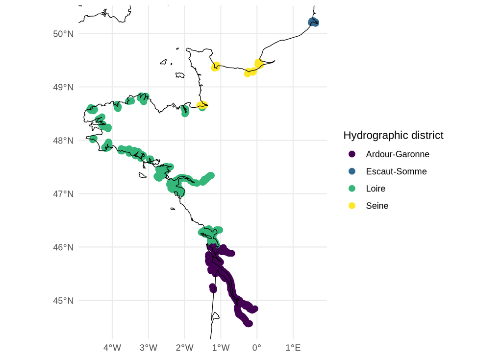

```r
fw_with_district <- tar_read(fw_with_district)

library(rnaturalearth)
library(rnaturalearthhires)
coastline <- ne_coastline(scale = "large", returnclass = "sf")

ggplot(fw_with_district, aes(x = longitude, y = latitude, color = district)) +
  geom_point(size = 2.5) +
  geom_sf(data = coastline, inherit.aes = FALSE, linewidth = 0.3) +
  scale_color_viridis_d() +
  coord_sf(
    xlim = range(fw_with_district$longitude),
    ylim = range(fw_with_district$latitude)
  ) +
  labs(x = NULL, y = NULL, color = "Hydrographic district")
```

We will later this classification to model it as a random effect to take into account the differences that can be due to the hydrographic bassin.

## First models

### Format the data

```r
# Food web with zone information (DCE hydrographic district).
district <- tar_read(fw_with_district) |>
  select(trait = operation_id, district, zone_id)

# Food web with environment information.
environment <- tar_read(fw_with_env) |>
  filter(dist_to_env < 5) |>
  select(-foodweb) |>
  mutate(
    salinity = scale(log10(sali_mean)) |> as.numeric(),
    chlorophyll = scale(chl_mean) |> as.numeric()
  ) |>
  rename(trait = operation_id)

size <- tar_read(foodweb_size_info)

data <- inner_join(district, environment, by = join_by(trait)) |>
  mutate(log_trophic_richness = scale(log_trophic_richness) |> as.numeric()) |>
  left_join(size, by = join_by(trait)) |>
  mutate(max_fish_size = tidyr::replace_na(max_fish_size, 0))
```

### SEM

```r
data <- data |>
  select(
    log_species_richness,
    log_trophic_richness,
    salinity,
    chlorophyll,
    temp_mean,
    frac_piscivorous,
    connectance,
    trophic_length,
    year,
    zone_id,
    survey,
    max_fish_size
  ) |>
  filter_out(is.na(zone_id)) |>
  mutate(zone_id = as.factor(zone_id)) |>
  mutate(max_fish_size = max_fish_size |> scale() |> as.numeric())

observable <- c("salinity", "chlorophyll", "temp_mean")
mediator <- c("log_species_richness", "max_fish_size", "frac_piscivorous")
response <- c("trophic_length", "connectance")
random <- c("(1 | year)", "(1 | zone_id)")
sem_model <- build_sem(observable, mediator, response, random, data)
piecewiseSEM::coefs(sem_model)
```

```
               Response            Predictor Estimate Std.Error   DF Crit.Value
1  log_species_richness             salinity   0.0306    0.0089 3286     3.4454
2  log_species_richness          chlorophyll   0.0434    0.0135 3286     3.2241
3  log_species_richness            temp_mean  -0.0148    0.0052 3286    -2.8629
4         max_fish_size             salinity   0.1032    0.0489 3286     2.1095
5         max_fish_size          chlorophyll   0.2201    0.0695 3286     3.1652
6         max_fish_size            temp_mean   0.0111    0.0229 3286     0.4822
7      frac_piscivorous             salinity  -0.0029    0.0074 3286    -0.3917
8      frac_piscivorous          chlorophyll   0.0280    0.0109 3286     2.5725
9      frac_piscivorous            temp_mean  -0.0079    0.0039 3286    -2.0310
10       trophic_length log_species_richness   1.0202    0.0267 3286    38.1836
11       trophic_length        max_fish_size   0.1378    0.0048 3286    28.7767
12       trophic_length     frac_piscivorous   1.1726    0.0316 3286    37.1466
13          connectance log_species_richness  -0.1216    0.0016 3286   -75.6657
14          connectance        max_fish_size   0.0058    0.0003 3286    20.2407
```

[output cut: 17 more lines]

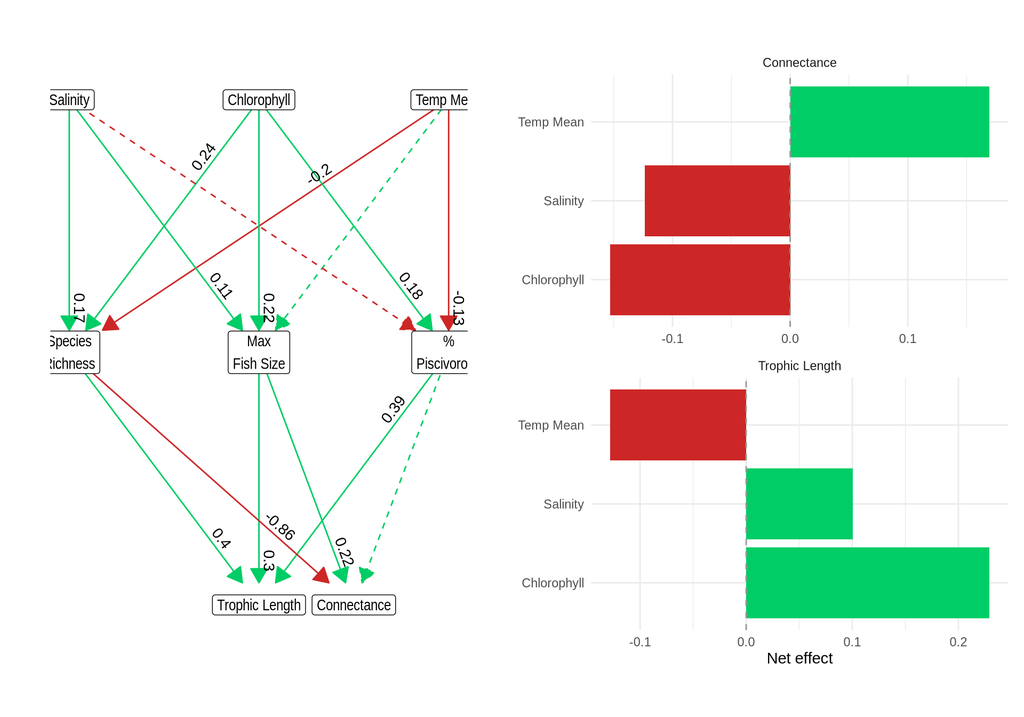

```r
plot_sem(sem_model)
```

### Fit the models

```r
library(INLA)

data <- data |>
  mutate(
    connectance = connectance |> scale() |> as.numeric(),
    trophic_length = trophic_length |> scale() |> as.numeric(),
  )

m_c <- inla(
  connectance ~ 1 + salinity * chlorophyll +
    f(year, model = "iid") + f(survey, model = "iid") +
    f(zone_id, model = "iid"),
  data = data
)

m_tl <- inla(
  trophic_length ~ 1 + salinity * chlorophyll +
    f(year, model = "iid") + f(survey, model = "iid") +
    f(zone_id, model = "iid"),
  data = data
)
```

### Visualise fixed effects

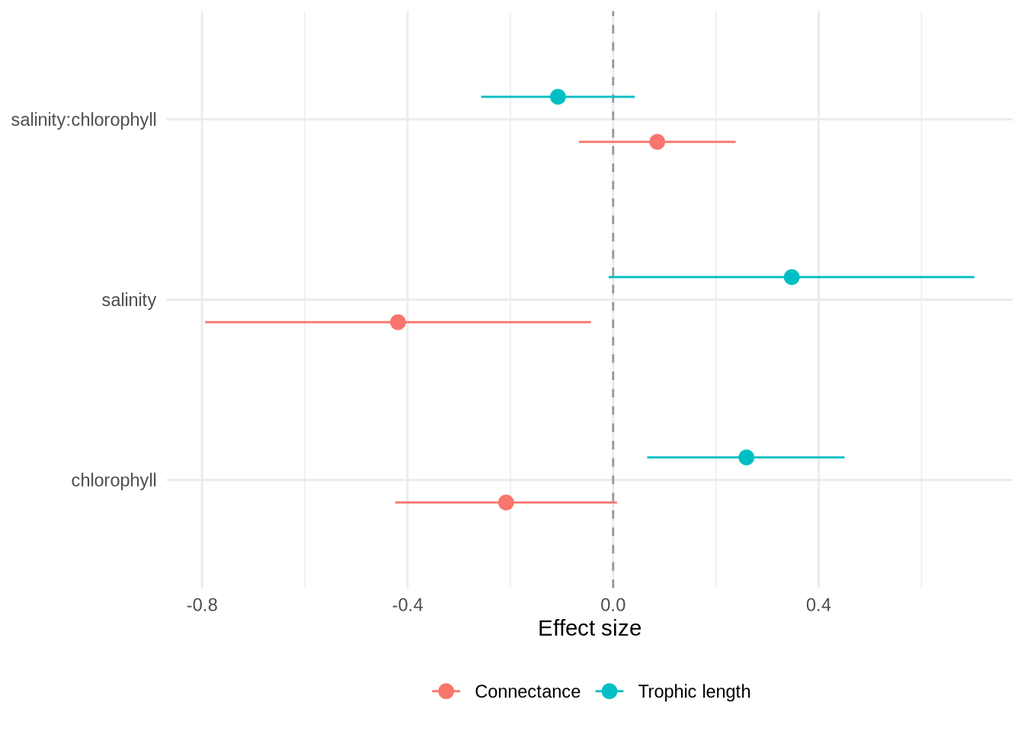

```r
extract_fixed <- function(model, model_name) {
  model$summary.fixed |>
    tibble::rownames_to_column("term") |>
    filter(term != "(Intercept)") |>
    mutate(model = model_name)
}

fixed <- bind_rows(
  extract_fixed(m_c, "Connectance"),
  extract_fixed(m_tl, "Trophic length")
)

ggplot(fixed, aes(x = mean, y = term, color = model)) +
  geom_vline(xintercept = 0, linetype = "dashed", color = "grey60") +
  geom_linerange(aes(xmin = `0.025quant`, xmax = `0.975quant`),
    position = position_dodge(width = 0.5)
  ) +
  geom_point(aes(x = `0.5quant`),
    size = 3,
    position = position_dodge(width = 0.5)
  ) +
  labs(x = "Effect size", y = NULL, color = NULL) +
  theme(legend.position = "bottom")
```

It is partly expected. Trophic structure can be shaped by three factors: trophic richness, individual sizes, and their predation window. As we have for now taken the same predation window for all species, only effect of environmental drivers on indivdual sizes could explain variation in trophic structure. Probably by refining predation window and species diet we will be able to capture an effect of environmental driver beyond pure richness effects.

If we further compare these two models, we see that the interaction between salinity and chlorophyll overlaps with zero, indicating that it does not influence community trophic length.

### Visualise marginal effets

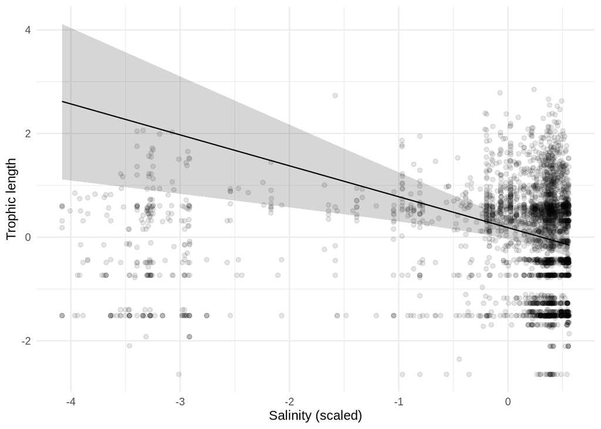

```r
salinity_vals <- seq(min(data$salinity), max(data$salinity), length.out = 100)

prediction_salinity <- data.frame(
  salinity    = salinity_vals,
  chlorophyll = 0, # held at mean (scaled)
  year        = NA,
  survey      = NA,
  district    = NA
)

data_pred <- bind_rows(data, prediction_salinity)
m_pred_salinity <- inla(
  connectance ~ 1 + salinity * chlorophyll +
    f(year, model = "iid") + f(survey, model = "iid") +
    f(zone_id, model = "iid"),
  data = data_pred,
  control.predictor = list(compute = TRUE, link = 1)
)

# extract predictions for the NA rows
n_obs <- nrow(data)
preds <- m_pred_salinity$summary.fitted.values[(n_obs + 1):(n_obs + 100), ]

prediction_salinity |>
  bind_cols(preds) |>
  ggplot(aes(x = salinity_vals)) +
  geom_ribbon(aes(ymin = `0.025quant`, ymax = `0.975quant`), alpha = 0.2) +
  geom_line(aes(y = mean)) +
  geom_point(data = data, aes(x = salinity, y = trophic_length), alpha = 0.1) +
  labs(x = "Salinity (scaled)", y = "Trophic length")
```

[figure not shown]

```r
chlorophyll_vals <- seq(
  min(data$chlorophyll), max(data$chlorophyll),
  length.out = 100
)

prediction_chlorophyll <- data.frame(
  chlorophyll = chlorophyll_vals,
  salinity = 0, # held at mean (scaled)
  year = NA,
  survey = NA,
  district = NA
)

data_pred <- bind_rows(data, prediction_chlorophyll)
m_pred_chlorophyll <- inla(
  connectance ~ 1 + salinity * chlorophyll +
    f(year, model = "iid") + f(survey, model = "iid") +
    f(zone_id, model = "iid"),
  data = data_pred,
  control.predictor = list(compute = TRUE, link = 1)
)

# extract predictions for the NA rows
n_obs <- nrow(data)
preds <- m_pred_chlorophyll$summary.fitted.values[(n_obs + 1):(n_obs + 100), ]

prediction_chlorophyll |>
  bind_cols(preds) |>
  ggplot(aes(x = chlorophyll_vals)) +
  geom_ribbon(aes(ymin = `0.025quant`, ymax = `0.975quant`), alpha = 0.2) +
  geom_line(aes(y = mean)) +
  geom_point(data = data, aes(x = chlorophyll, y = trophic_length), alpha = 0.1) +
  labs(x = "Chlorophyll (scaled)", y = "Trophic length")
```

### Visualise random effects

#### Temporal

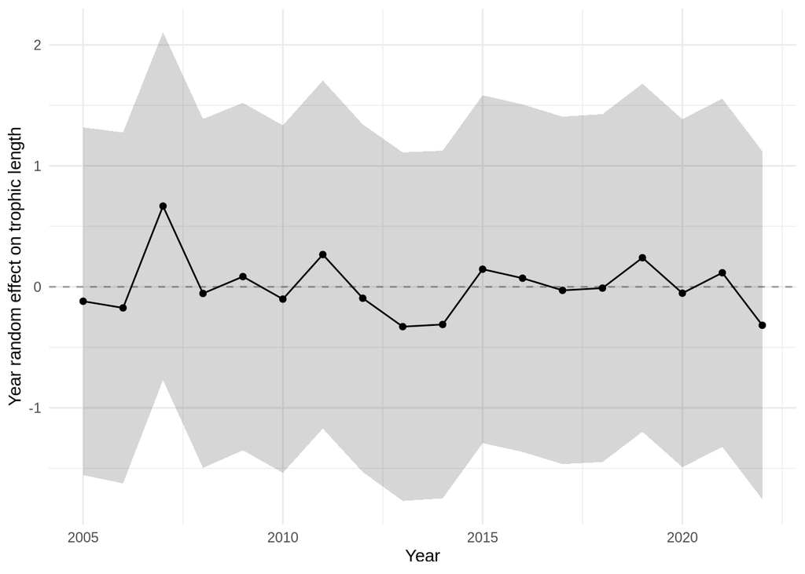

```r
year_re <- m_c$summary.random$year |>
  as_tibble() |>
  rename(year = ID)

ggplot(year_re, aes(x = year, y = mean)) +
  geom_hline(yintercept = 0, linetype = "dashed", color = "grey60") +
  geom_ribbon(aes(ymin = `0.025quant`, ymax = `0.975quant`), alpha = 0.2) +
  geom_line() +
  geom_point() +
  labs(x = "Year", y = "Year random effect on trophic length") +
  theme_minimal()
```

#### Spatial

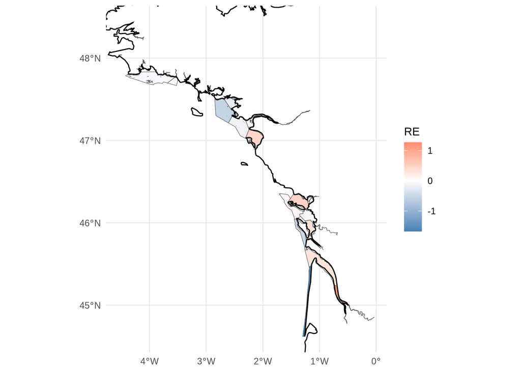

```r
area <- tar_read(hydrographic_area)
spatial_re <- m_c$summary.random$zone_id |>
  as_tibble() |>
  rename(zone_id = ID) |>
  left_join(area, by = join_by(zone_id)) |>
  st_as_sf()

bbox <- st_bbox(spatial_re)

ggplot(spatial_re) +
  geom_sf(aes(fill = mean)) +
  geom_sf(data = coastline) +
  scale_fill_gradient2(
    low = "steelblue", mid = "white", high = "tomato",
    midpoint = 0, name = "RE"
  ) +
  coord_sf(
    xlim = c(bbox["xmin"], bbox["xmax"]),
    ylim = c(bbox["ymin"], bbox["ymax"])
  ) +
  labs(x = NULL, y = NULL)
```